# 民主政治 政治民主化：浪潮與解釋

師大公領系教授 黃信豪

2020/11

### 關於民粹主義的評論

[以毒攻毒的政治再進化：歐洲「民粹政黨」要滅絕了嗎？](https://global.udn.com/global_vision/story/8663/4967315)  
[《民粹主義【21世紀公民的思辨課】》：我們 vs. 外人，分辨民粹主義者的十大特徵](https://www.thenewslens.com/article/142024)  
[有才能的人統治社會， 為何被民粹顛覆？](https://www.bnext.com.tw/article/59912/meritocracy)

### Topics

**一、政治民主化：概念與定義**  
**二、民主化的浪潮：從第一波到第三波**  
**三、解釋政治民主化**  
**四、小結：民主化與民主治理**

**指定閱讀：民主的精神，Ch.2-6；第三波：二十世紀末的民主化浪潮，Ch.1-4。**

# 一、政治民主化：概念與定義

### （一）政體類型：從「國家控制力」出發

- 政治學的政體類型發展：民主、極權 $\rightarrow$ 威權。
- 民主政體(democracy)、非民主政體(non-democracy)
  - 1.極權政體(totalitarianism)：政府/國家機器的控制力全面，遍及政治、經濟、社會、文化等 $\rightarrow$ 具有徹底改造社會的意識型態、組織嚴密黨機器等。
  - 2.威權政體(authoritarianism)：政府/國家機器的控制力主要在政治場域，對於非政治性領域則較為寬鬆 $\rightarrow$ 可能允許市場經濟、社會有限多元等…
    - 有許多不同形式：君主、宗教、軍人、政黨型威權等…

### （二）政治民主化(democratization)

- 定義：一個國家從**非民主政體**轉變為**民主政體**的過程：非民主政體(non D) $\rightarrow$ 轉型中民主政體(transitional D) $\rightarrow$ 穩固民主政體(consolidated D)。
  - Two steps：(1)民主轉型；(2)民主鞏固。
  - Note:早期民主化研究大多預設線性發展，晚近有不同看法。
- 判準：到什麼程度才是「鞏固」？有什麼可參考標準？
  - 1.二次政黨輪替論(two-turnover test, Huntington 1991)：當經歷兩次政黨輪替，表示一個社會兩個主要政治集團願意按照選舉結果交出職位與政治權力。
    - 依循「菁英民主理論」預設：統治者願意接受選舉結果（失敗者），為民主核心意義。
  - 2.民主鞏固指標(Diamond 1999)：**菁英**、**社會組織**、**大眾**所展現出對**民主制度**的**價值信念、態度與行為** $\rightarrow$ 具「民主正當性」(democratic legitimacy)。
    - 價值信念、態度與行為：相信民主是最好的政體形式；接受、尊重民主程序的結果；無尋求推翻民主體制或採用非民主方式追求權力與其他目標等…。
    - 菁英：各領域重要的領導人與領袖。
    - 社會組織：重要政黨、利益團體等組織團體（含社會運動）。
    - 大眾(over 70%)。
  - 結果：民主成為唯一的遊戲規則(the only game in town, Linz & Stepan 1996) $\rightarrow$ 當公共生活出了問題，我們欲改變的是**統治者**(ruler)，不是這個**體制**(regime)。
- Q. Taiwan 是否已達民主鞏固？未來可能的挑戰？
- Q.民主未來的前景？再論「民主正當性」？
  - 理念(ideal)正當性：民主相關價值（自由、平等、多元….）。
  - 程序(procedural)正當性：正當性的自我更新機制。
  - 績效(performance-based)正當性：對政府政策產出、治理表現的評價?國內因素（媒體$\rightarrow$ 民眾批判傾向）、國際因素（經濟表現受影響）。
    - 績效問題可透過程序滿足。

# 二、民主化的浪潮：從第一波到第三波

- 民主化浪潮：在同一時期內，一群國家政體由非民主轉型至民主；Huntington(1991)認為有三波民主化**浪潮**，也有**回潮**。

### （一）第一波民主化：1828-1926；自美國革命、法國大革命

- 民主最低限度標準（與今日不同）。
- 擴大普選權的浪潮(19th 後半)：約30幾個國家，集中在**歐洲、北美、英海外領地**。共同點?
- 回潮：1922-1942，法西斯主義與軍人專政。背景？

### （二）第二波民主化： 1943-1962，二次大戰及其後

- 盟軍**推進**民主制度、**新興獨立**國家 $\rightarrow$ 共約50個國家。
- 回潮：1958-1975，威權復僻與軍事政變，拉美、印尼、非洲國家等（包括臺灣）。
- 威權統治的基礎改變：無公開反對「民主」詞彙的言行，甚至宣稱自己是民主的一方；訴求**績效正當性**。

### （三）第三波民主化：1974-1990，葡、西、希、中南美、亞州、共產世界、南非等。

- 地域全面，共約60多個國家（當時未有回潮；仍有某些地區有障礙）。
- 小結：三波的發展後果
  - 1.生活在民主統治的人口明顯增加。
  - 2.民主化是全球性的浪潮，即使有退潮，進兩步退一步。
  - 3.民主在**意識型態**上勝利，但作為一種**政治體制**則未必。

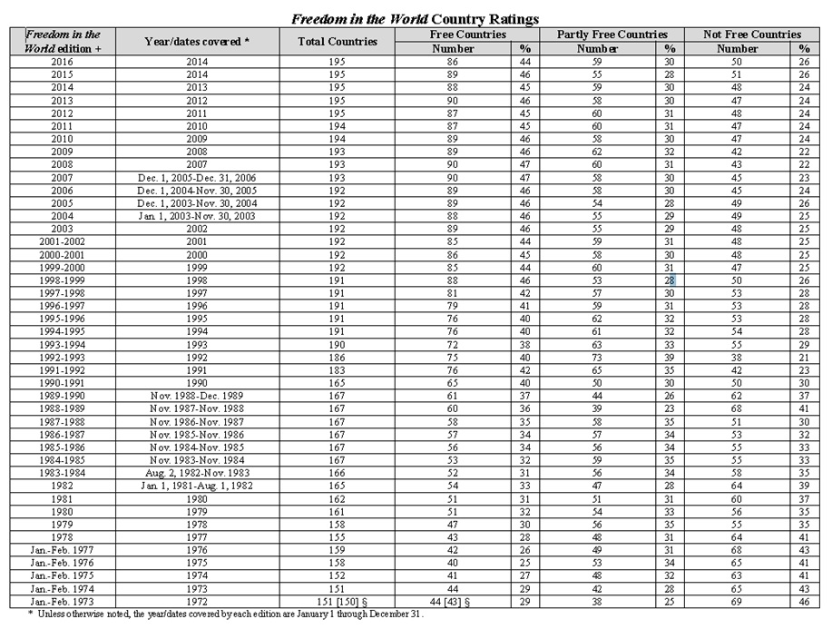

### （四） 新浪潮：第四波民主化(？)

- 2010-，茉莉花革命/阿拉伯之春，北非、中東國家 $\rightarrow$ 成功案例少。
- 大多屬穆斯林國家、肇因於民生問題 $\rightarrow$ 威權統治的績效正當性衰退。
  - 伊斯蘭社會的民主化障礙：宗教因素(？)

# 三、解釋政治民主化

- 那些條件/因素可以解釋/理解一個國家為何走向政治民主化？
  - 社會科學的基礎認識：
    - 1.不完美解釋。沒有單一的**必要條件** or **充分條件**。
    - 2.民主發展通常是不同因素的綜合組合。
    - 3.從個別因素來看，通常各國、不同時空下作用也不同。
- Note:通則化（generalization）是很困難的，很難，但不代表要放棄。

### （一）Huntington(1991)的針對不同浪潮的歸納

- 第一波民主化：(1)親民主思想；(2)社會、經濟發展；(3)殖民母國的影響；(4)西方協約國的勝利。
- 第二波民主化：(1)西方同盟國的勝利、(2)去殖民化影響。
- 第三波民主化：(1)經濟發展；(2)經濟危機與**績效困境(performance dilemma)** ；(3)宗教（基督新教）的推廣影響；(4)國外勢力的影響；(5)滾雪球效應；(6)領導人的決策。
  - 較無理論化，主要是針對不同時空環境提出解釋。從理念(ideal)、績效(perfomance)正當性整理三波民主化
  - 「臺灣」的故事？第三波的因素哪些在臺灣適用？哪些則否？

### （二）解釋政治民主化的理論取徑(approach)

- 1.條件論：(1)社會經濟理論、(2)政治文化理論、(3)國際影響理論
  - 嘗試勾勒有利民主政治出現的條件 $\rightarrow$ 侷限？
- 2.過程解釋途徑：從政治菁英互動、權衡理解民主機制如何出現(based on rational choices)？侷限？
- 兩者解釋皆部分非全貌 $\rightarrow$ 社會科學理論的trade-off：強調「通則化」 (theory-oriented) or「個案」(case-oriented)？
- **(1)社會經濟理論：社會經濟條件 $\rightarrow$ 政治民主化？**
  - 現代化理論/典範：社會經濟發展/現代化 $\rightarrow$ 社會流動（都市化、中產階級興起） $\rightarrow$ 教育普及、資訊流傳、大眾傳媒興起 $\rightarrow$ 民眾權利意識、對參政/民主程序的要求。
  - 經濟條件論：社會經濟現況 $\rightarrow$ 對執政當局的看法（正當性危機）。
    - 解釋民主出現，也解釋民主衰退。
  - 差異：長期、短期；經濟發展「程度」、「速度」。
  - 侷限：1.外在物質環境與主觀意識的關係？2.「民眾」角色的重要性？3.時機？
  - 社會經濟條件對民主化的影響很複雜，晚近較強調對民主政治**維持**的影響，而非促進。
- **(2)政治文化理論：傳統文化 $\rightarrow$ 政治民主化？**
  - 政治文化：一國大眾對政治體系集體的認知、情感與評價。民眾是否、如何因特定**傳統**，而普遍存在特定政治傾向？
    - 有利民主發展的傳統政治文化：新教文化區 $\rightarrow$ 個人主義（如平等的親民主價值）。
    - 不利於民主發展的傳統政治文化：
      - (1)儒家文化區：對不同社會關係的行為準則、規範 $\rightarrow$ A.家父長式主義；B.服從的階層意識；C.強調個人責任>權利）
      - (2)伊斯蘭文化區：政教合一傾向 $\rightarrow$ 對權威的全面順從。
  - 侷限：「文化」長期存在且不容易改變，如何解釋政體轉型？時機？
  - 晚近研究強調是促進或妨礙的社會條件，但無絕對影響。
  - 社會經濟、政治文化理論：個人「親民主態度」都是關鍵的中介因素。
- **(3)國際影響理論：國際政治 $\rightarrow$ 本國政治民主化？**
  - 國際政治的可能影響：挑戰、依賴、示範。
    - 挑戰：國際上的競爭，促使本國政策與制度上的調整。
    - 依賴：因跟外國的關係，本國政治發展深受外國影響。
    - 示範：受到外國（通常是鄰近國家）改變的影響，本國進而仿效、學習外國的制度。
  - 侷限：時機？無法明確解釋亞洲民主化（如臺灣、南韓）、持續共黨政權（中國、北韓）。
- **(4)過程解釋途徑：政治菁英互動**
  - 條件論觀點存有許多**異例** $\rightarrow$ 理論有解釋力嗎？
    - 思考不同條件（社會經濟長期、短期；政治文化、國際影響）的符合、不符合案例？
  - 過程解釋：**著重政治行動者的互動及其後果 $\rightarrow$ 民主政治可能是預期or 非預期的結果，具路徑依賴(path-dependency)性質。**
    - 民主化的契機(chance)：
      - 威/極權政權中的改革派當政：(1)改革帶來非預期結果，如蘇聯；(2)廣納社會成分，原有執政團體分裂？如KMT
      - 民主制度作為「共識」的出現（ O’Donnell等人 1986）：(1)區分四類的行動者：政權中的改革派、強硬派；反對力量中的溫和派、激進派；(2)促成民主轉型**最有利的途徑是政權中改革派與反對力量中溫和派結盟** $\rightarrow$ 漸進的民主化。
  - 侷限：可比較性、理論可通則性

# 四、小結：民主化與民主治理

- 1.20世紀的民主化浪潮：民主政體是人們政治生活最可長可久的模式。
  - 作為「意識型態」已勝利，「制度型態」勝利還有很長的路要走。
- 2.民主鞏固與深化是持續的過程：轉型中民主政體**不必然**會往穩固民主政體方向持續前進。
  - 缺乏完全競爭(**控制式民主國家**)、缺乏公民權利的廣泛保障(**選舉式民主國家**) $\rightarrow$ 只有**統治者願意接受民主規則約束，放棄權力**，民主才實質存在。
- 3.民主的可能不同型態？liberal D是唯一的發展模式、終點嗎？
- 4.民主穩固不代表不會出現「治理」危機：(1)新興民主國家的國家能力、(2)西方民主國家的經濟危機、貧富差距擴大。